# Week 2 exercises

Dmitry Kondrashov and Stefano Allesina

## Goals:

In this assignment you will do the following:

- Calculate conditional probabilities from data sets in tibble format using logical statements
- Use probability distribution functions and random number generators for calculations
- Generate sample means and calculate confidence intervals to investigate their performance

## Grading:

Part 1: 3 pts each, 6 total Part 2: 4 pts each, 12 total Part 3: 5 pts each, 10 total + 2 pts for submission Total: 30 pts

## Part 1: Conditional probabilities

Let us use the Titanic passenger data set, specifically the titanic_train tibble:

```r
library(titanic)
head(titanic_train)
```

```
##   PassengerId Survived Pclass
## 1           1        0      3
## 2           2        1      1
## 3           3        1      3
## 4           4        1      1
## 5           5        0      3
## 6           6        0      3
##                                                  Name    Sex Age SibSp
## 1                             Braund, Mr. Owen Harris   male  22     1
## 2 Cumings, Mrs. John Bradley (Florence Briggs Thayer) female  38     1
## 3                              Heikkinen, Miss. Laina female  26     0
## 4        Futrelle, Mrs. Jacques Heath (Lily May Peel) female  35     1
## 5                            Allen, Mr. William Henry   male  35     0
## 6                                    Moran, Mr. James   male  NA     0
##   Parch           Ticket    Fare Cabin Embarked
## 1     0        A/5 21171  7.2500              S
## 2     0         PC 17599 71.2833   C85        C
## 3     0 STON/O2. 3101282  7.9250              S
## 4     0           113803 53.1000  C123        S
## 5     0           373450  8.0500              S
## 6     0           330877  8.4583              Q
```

1. Calculate and report the conditional probability of survival for men and women and compare with the survival probability for all passengers.

```r
ans <- sum((titanic_train$Survived))/length(titanic_train$Survived)
paste("overall survival rate for passengers:", ans)
```

```
## [1] "overall survival rate for passengers: 0.383838383838384"
```

```r
ans <- sum((titanic_train$Sex == 'male')*(titanic_train$Survived))/sum(titanic_train$Sex == 'male')
paste("survival rate for all males:", ans)
```

```
## [1] "survival rate for all males: 0.188908145580589"
```

```r
ans <- sum((titanic_train$Sex == 'female')*(titanic_train$Survived))/sum(titanic_train$Sex == 'female')

paste("survival rate for all females:", ans)
```

```
## [1] "survival rate for all females: 0.74203821656051"
```

There is clearly a huge difference between survival probabilities for men and women.

2. Suppose there is a hypothesis that the difference in survival rates for different passenger classes is due to different fractions of males and females. To check if this is plausible, calculate the survival rates for males and females separately for three passenger classes.

```r
ans <- sum((titanic_train$Sex == 'male')*(titanic_train$Survived)*(titanic_train$Pclass==1))/sum((titanic_train$Sex == 'male')*(titanic_train$Pclass==1))
paste("survival rate for males in first class:", ans)
```

```
## [1] "survival rate for males in first class: 0.368852459016393"
```

```r
ans <- sum((titanic_train$Sex == 'female')*(titanic_train$Pclass==1)*(titanic_train$Survived))/sum((titanic_train$Sex == 'female')*(titanic_train$Pclass==1))
paste("survival rate for females in first class:", ans)
```

```
## [1] "survival rate for females in first class: 0.968085106382979"
```

```r
ans <- sum((titanic_train$Sex == 'male')*(titanic_train$Survived)*(titanic_train$Pclass==2))/sum((titanic_train$Sex == 'male')*(titanic_train$Pclass==2))
paste("survival rate for males in second class:", ans)
```

```
## [1] "survival rate for males in second class: 0.157407407407407"
```

```r
ans <- sum((titanic_train$Sex == 'female')*(titanic_train$Pclass==2)*(titanic_train$Survived))/sum((titanic_train$Sex == 'female')*(titanic_train$Pclass==2))
paste("survival rate for females in second class:", ans)
```

```
## [1] "survival rate for females in second class: 0.921052631578947"
```

```r
ans <- sum((titanic_train$Sex == 'male')*(titanic_train$Survived)*(titanic_train$Pclass==3))/sum((titanic_train$Sex == 'male')*(titanic_train$Pclass==3))
paste("survival rate for males in third class:", ans)
```

```
## [1] "survival rate for males in third class: 0.135446685878963"
```

```r
ans <- sum((titanic_train$Sex == 'female')*(titanic_train$Pclass==3)*(titanic_train$Survived))/sum((titanic_train$Sex == 'female')*(titanic_train$Pclass==3))
paste("survival rate for females in third class:", ans)
```

```
## [1] "survival rate for females in third class: 0.5"
```

Simply comparing the survival probabilities for men and women conditioned on class, there is a very large difference between survival rate of men in first class compared to men in other classes, and a huge difference between survival of women in third class compared to women in the other classes. This suggests that survival, even separated by sex, still depended on class.

## Part 2: Distributions and their properties

Use scripts from the Tuesday lecture.Rmd file to plot the distributions and calculate their expectations and variances and compare them to the theoretical predictions.

1. Uniform distribution (discrete). Plot the distribution over the ranges [0,20] and [-10, 30], report the respective expectations and variances and compare them to the theoretical values (look it up if you can’t calculate or deduce the relationship by experimenting).

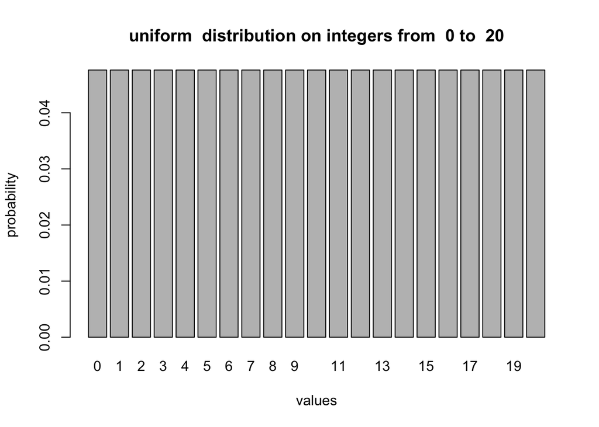

```r
low <- 0 # minimum value
high <- 20 # maximum value
values <- low:high # vactor of discrete values of the RV
num <- length(values)
probs <- rep(1/num, num) # uniform mass function vector
barplot(probs, names.arg = values, xlab = 'values', ylab = 'probability',
        main = paste("uniform  distribution on integers from ", low, "to ", high))
```

```r
unif.exp <- sum(values*probs)
paste("The expected value of uniform distribution is", unif.exp)
```

```
## [1] "The expected value of uniform distribution is 10"
```

```r
paste("The theoretical expected value is", (high+low)/2)
```

```
## [1] "The theoretical expected value is 10"
```

```r
unif.var <- sum((unif.exp - values)^2*probs)
paste("The variance of uniform distribution is", unif.var)
```

```
## [1] "The variance of uniform distribution is 36.6666666666667"
```

```r
paste("The theoretical variance is", ((high-low+1)^2-1)/12)
```

```
## [1] "The theoretical variance is 36.6666666666667"
```

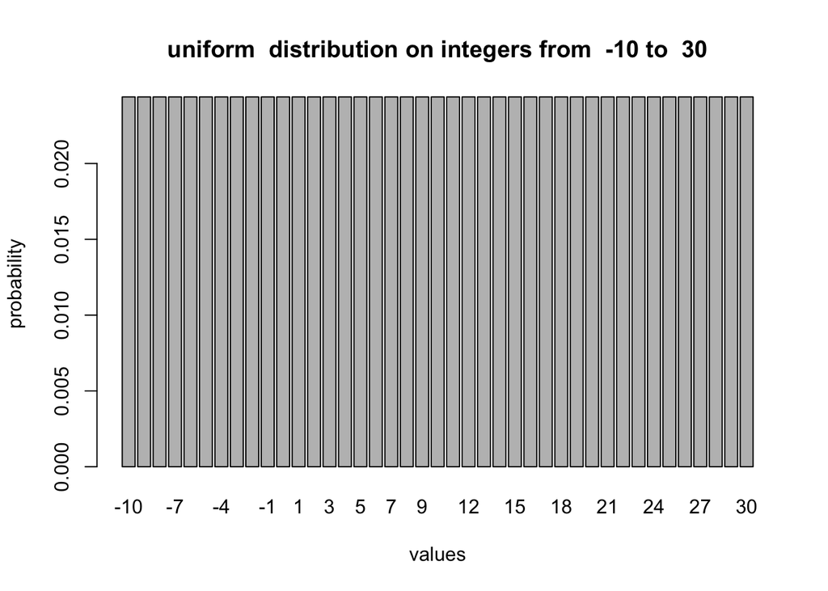

```r
low <- -10 # minimum value
high <- 30 # maximum value
values <- low:high # vactor of discrete values of the RV
num <- length(values)
probs <- rep(1/num, num) # uniform mass function vector
barplot(probs, names.arg = values, xlab = 'values', ylab = 'probability',
        main = paste("uniform  distribution on integers from ", low, "to ", high))
```

```r
unif.exp <- sum(values*probs)
paste("The expected value of uniform distribution is", unif.exp)
```

```
## [1] "The expected value of uniform distribution is 10"
```

```r
paste("The theoretical expected value is", (high+low)/2)
```

```
## [1] "The theoretical expected value is 10"
```

```r
unif.var <- sum((unif.exp - values)^2*probs)
paste("The variance of uniform distribution is", unif.var)
```

```
## [1] "The variance of uniform distribution is 140"
```

```r
paste("The theoretical variance is", ((high-low+1)^2-1)/12)
```

```
## [1] "The theoretical variance is 140"
```

For a uniform random variable $X$ on the set of consecutive integers $X={a,...,b}$, the expected value is $E(X) = (b+a)/2$. The variance is a bit more tricky and turns out to have the following relationship: $Var(X) = ((b-a+1)^2 -1)/12$. Calculations in the script above show agreement between these general formulas and the expectations and variances for specific parameter values.

2. Binomial distribution. Plot the distribution for n=20 and p=0.3, for n=10 and p=0.6, and for n= 40 and p = 0.5; report the respective expectations and variances and compare them to theoretical dependence on n and p (look it up if you can’t calculate or deduce the relationship by experimenting).

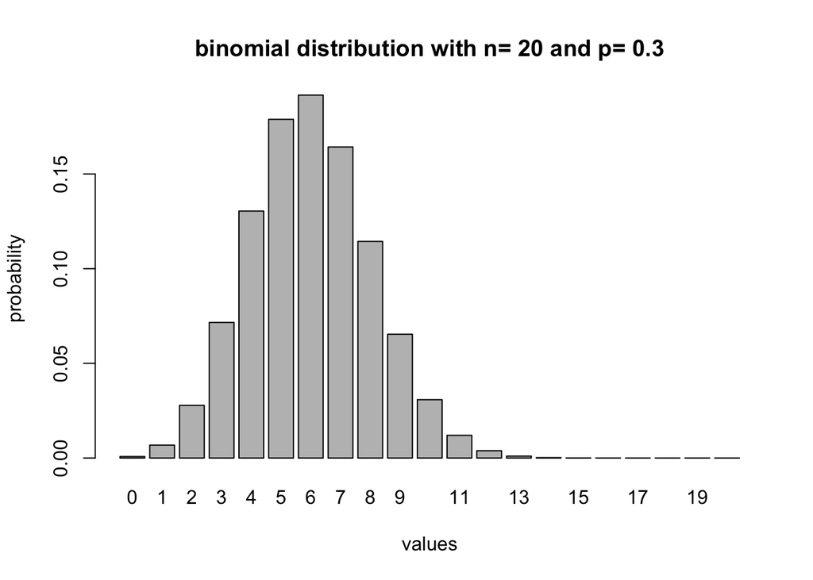

```r
n <- 20 # the number of trials
p <- 0.3 # the probability of success in one trial
values <- 0:n # vactor of discrete values of the binomial
probs <- dbinom(values, n, p)
barplot(probs, names.arg = values, xlab = 'values', ylab = 'probability',
        main = paste("binomial distribution with n=", n, "and p=", p))
```

```r
bin.exp <- sum(values*probs)
paste("The expected value of binomial distribution is", bin.exp)
```

```
## [1] "The expected value of binomial distribution is 6"
```

```r
paste("The theoretical expected value is", n*p)
```

```
## [1] "The theoretical expected value is 6"
```

```r
bin.var <- sum((bin.exp - values)^2*probs)
paste("The variance of binomial distribution is", bin.var)
```

```
## [1] "The variance of binomial distribution is 4.2"
```

```r
paste("The theoretical variance is", n*p*(1-p))
```

```
## [1] "The theoretical variance is 4.2"
```

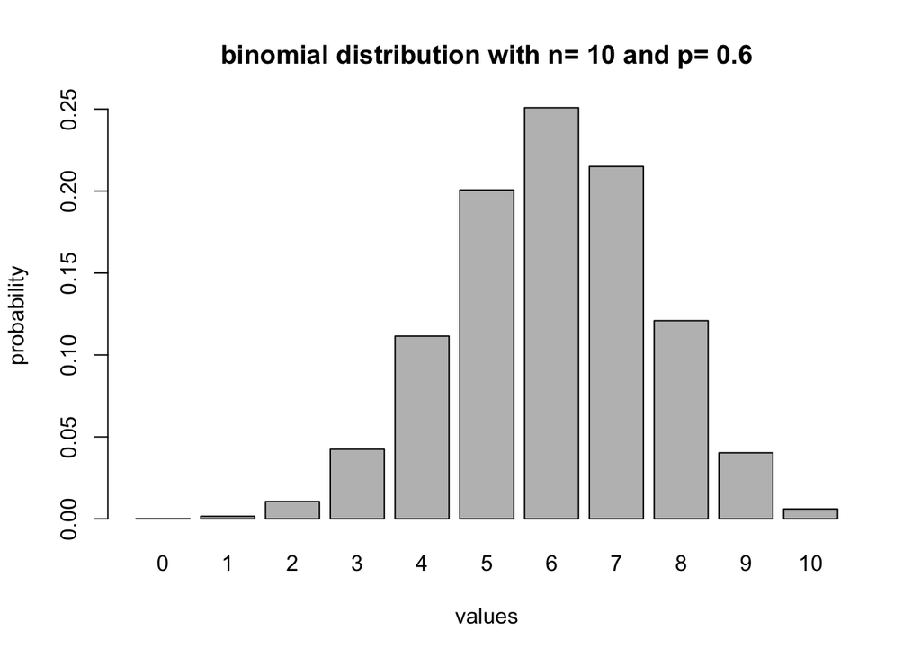

```r
n <- 10 # the number of trials
p <- 0.6 # the probability of success in one trial
values <- 0:n # vactor of discrete values of the binomial
probs <- dbinom(values, n, p)
barplot(probs, names.arg = values, xlab = 'values', ylab = 'probability',
        main = paste("binomial distribution with n=", n, "and p=", p))
```

```r
bin.exp <- sum(values*probs)
paste("The expected value of binomial distribution is", bin.exp)
```

```
## [1] "The expected value of binomial distribution is 6"
```

```r
paste("The theoretical expected value is", n*p)
```

```
## [1] "The theoretical expected value is 6"
```

```r
bin.var <- sum((bin.exp - values)^2*probs)
paste("The variance of binomial distribution is", bin.var)
```

```
## [1] "The variance of binomial distribution is 2.4"
```

```r
paste("The theoretical variance is", n*p*(1-p))
```

```
## [1] "The theoretical variance is 2.4"
```

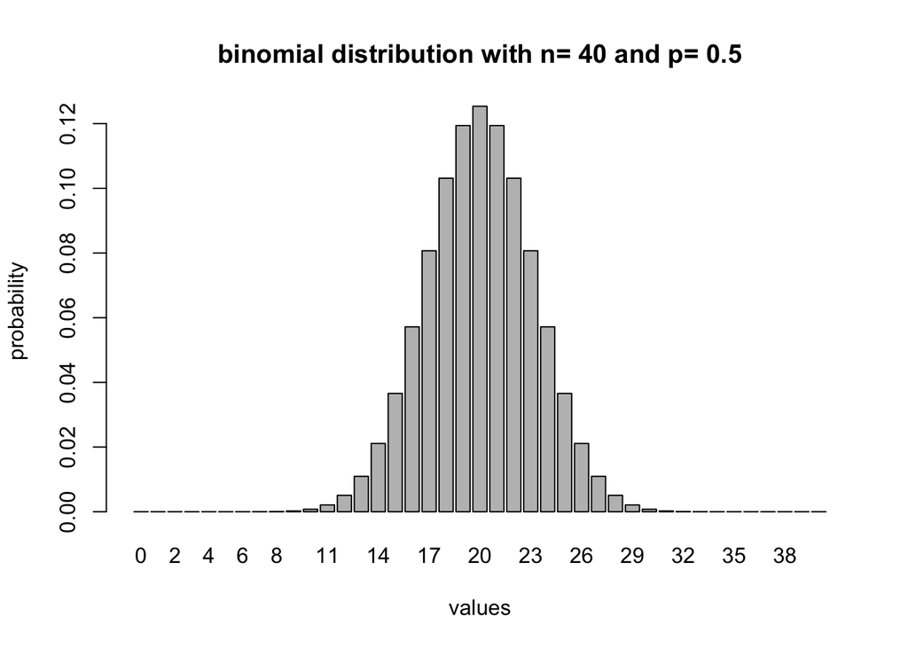

```r
n <- 40 # the number of trials
p <- 0.5 # the probability of success in one trial
values <- 0:n # vactor of discrete values of the binomial
probs <- dbinom(values, n, p)
barplot(probs, names.arg = values, xlab = 'values', ylab = 'probability',
        main = paste("binomial distribution with n=", n, "and p=", p))
```

```r
bin.exp <- sum(values*probs)
paste("The expected value of binomial distribution is", bin.exp)
```

```
## [1] "The expected value of binomial distribution is 20"
```

```r
paste("The theoretical expected value is", n*p)
```

```
## [1] "The theoretical expected value is 20"
```

```r
bin.var <- sum((bin.exp - values)^2*probs)
paste("The variance of binomial distribution is", bin.var)
```

```
## [1] "The variance of binomial distribution is 9.99999999999999"
```

```r
paste("The theoretical variance is", n*p*(1-p))
```

```
## [1] "The theoretical variance is 10"
```

For a binomial random variable $X$ with number of trials $n$ and probability $p$, the expected value is $E(X) = np$. The variance (which can be calculated as sum of the variances of $n$ identical Bernoulli processes) is: $Var(X) = np(1-p)$. Calculations in the script above show agreement between these general formulas and the expectations and variances for specific parameter values.

3. Geometric distribution. Plot the distribution for p=0.2, p = 0.5, and p=0.7, report the respective expectations and variances and compare them to theoretical dependence on p (look it up if you can’t calculate or deduce the relationship by experimenting).

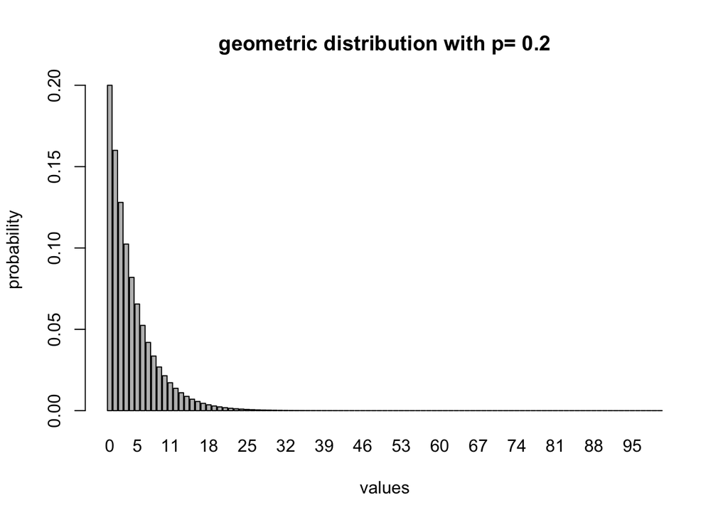

```r
p <- 0.2 # the probability of success
low <- 0 # minimum value
high <- 100 # maximum value
values <- low:high # vactor of discrete values of the RV
probs <- dgeom(values, p)
barplot(probs, names.arg = values, xlab = 'values', ylab = 'probability',
        main = paste("geometric distribution with p=", p))
```

```r
geom.exp <- sum(values*probs)
paste("The expected value of geometric distribution is", geom.exp)
```

```
## [1] "The expected value of geometric distribution is 3.9999999828889"
```

```r
paste("The theoretical expected value is", (1-p)/p)
```

```
## [1] "The theoretical expected value is 4"
```

```r
geom.var <- sum((geom.exp - values)^2*probs)
paste("The variance of geometric distribution is", geom.var)
```

```
## [1] "The variance of geometric distribution is 19.9999983343564"
```

```r
paste("The theoretical variance is", (1-p)/p^2)
```

```
## [1] "The theoretical variance is 20"
```

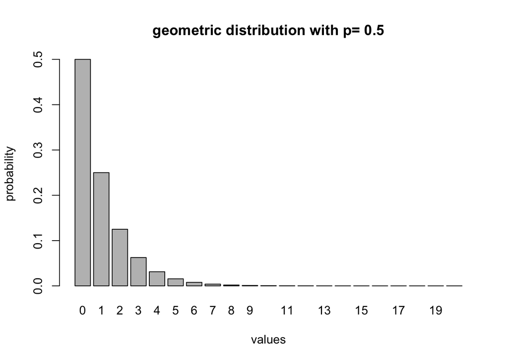

```r
p <- 0.5 # the probability of success
low <- 0 # minimum value
high <- 20 # maximum value
values <- low:high # vactor of discrete values of the RV
probs <- dgeom(values, p)
barplot(probs, names.arg = values, xlab = 'values', ylab = 'probability',
        main = paste("geometric distribution with p=", p))
```

```r
geom.exp <- sum(values*probs)
paste("The expected value of geometric distribution is", geom.exp)
```

```
## [1] "The expected value of geometric distribution is 0.99998950958252"
```

```r
paste("The theoretical expected value is", (1-p)/p)
```

```
## [1] "The theoretical expected value is 1"
```

```r
geom.var <- sum((geom.exp - values)^2*probs)
paste("The variance of geometric distribution is", geom.var)
```

```
## [1] "The variance of geometric distribution is 1.99978876103887"
```

```r
paste("The theoretical variance is", (1-p)/p^2)
```

```
## [1] "The theoretical variance is 2"
```

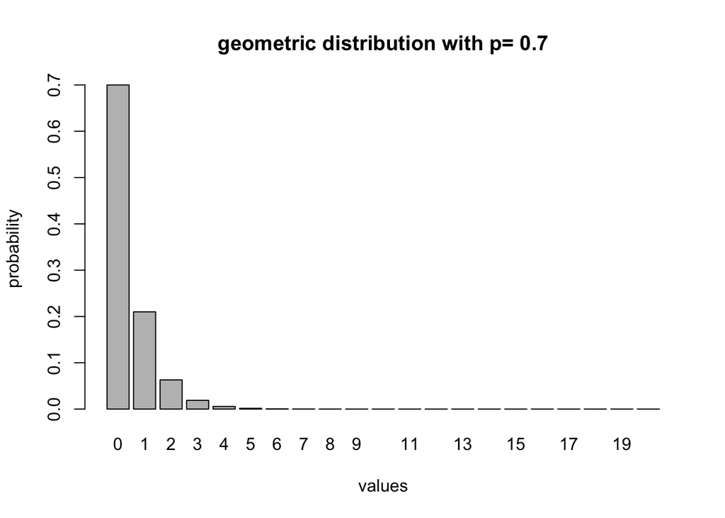

```r
p <- 0.7 # the probability of success
low <- 0 # minimum value
high <- 20 # maximum value
values <- low:high # vactor of discrete values of the RV
probs <- dgeom(values, p)
barplot(probs, names.arg = values, xlab = 'values', ylab = 'probability',
        main = paste("geometric distribution with p=", p))
```

```r
geom.exp <- sum(values*probs)
paste("The expected value of geometric distribution is", geom.exp)
```

```
## [1] "The expected value of geometric distribution is 0.428571428347278"
```

```r
paste("The theoretical expected value is", (1-p)/p)
```

```
## [1] "The theoretical expected value is 0.428571428571429"
```

```r
geom.var <- sum((geom.exp - values)^2*probs)
paste("The variance of geometric distribution is", geom.var)
```

```
## [1] "The variance of geometric distribution is 0.612244893339764"
```

```r
paste("The theoretical variance is", (1-p)/p^2)
```

```
## [1] "The theoretical variance is 0.612244897959184"
```

There are two different versions of the geometric distribution: the one that represents the number of trials before the first success (which can take values starting at 0) and the number of trials at the first success (which can take values starting at 1). The geometric distribution as implemented in R is the first version, and its expectation is $E(X) = 1/p - 1 = (1-p)/p$. The variance of either version is the same: $Var(X) = (1-p)/p^2$. Calculations in the script above show agreement between these general formulas and the expectations and variances for specific parameter values.

## Part 3: Confidence intervals vs reality

1. The script below generates samples from the discrete uniform distribution between 0 and 10, plots the distribution of sample means, and compared it with the normal distribution with the theoretical mean and standard error. Modify the script to produce samples from the binomial distribution with different values of p and n, and report how well the sample means agree with the theoretical normal distribution. Remember to change the calculations for mu and sigma.

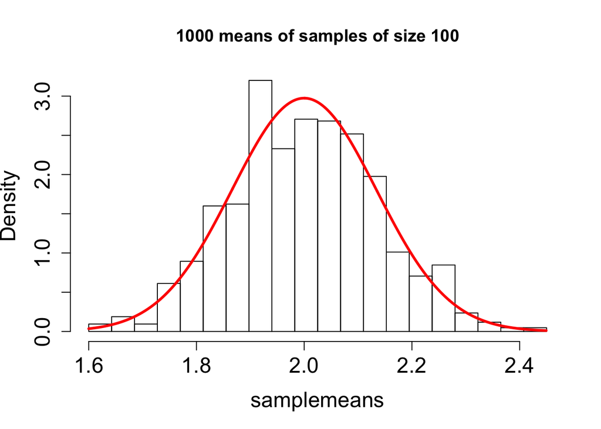

```r
numsamples <- 1000
samplemeans<-rep(NA, numsamples)
size<-100
n <- 20
p <- 0.1
for (i in 1:numsamples) {
  sample <- rbinom(size, n, p)
  samplemeans[i] <- mean(sample)
}
break_points <- seq(min(samplemeans),max(samplemeans),
                    (max(samplemeans)-min(samplemeans))/20)
hist(samplemeans, breaks=break_points, freq=FALSE, cex.axis=1.5, cex.lab=1.5,
     main= paste(numsamples, 'means of samples of size', size))
sigma<-sqrt(n*p*(1-p)/size) # standard error for the distribution
mu<-n*p # true mean of the distribution
range <- seq(min(samplemeans),max(samplemeans), sigma/100)
lines(range,dnorm(range,mu,sigma),t='l',lwd=3,col=2,lty=1,cex.axis=1.5,cex.lab=1.5)
```

For a skewed population distribution, e.g. with $p=0.1$, the sampling distribution of means looks pretty ragged for 100 samples, but it converges nicely to the normal distribution with mean $\mu = np$ and standard deviation (standard error) $\sigma = \sqrt{np(1-p)/N}$, where $N$ is the number of samples.

2. The following script calculates a confidence interval based on a sample. The z-value is the width of the interval measured in multiples of standard deviations of the normal distribution (standard errors) required for the interval to contain the probability density equal to the significance level $\alpha$, which theoretically should be the fraction of confidence intervals (out of many) that contain the true mean.

Modify the script to report whether the confidence interval contains the true mean. Use a loop structure (as in the script above) to generate 1000 sample means and report how many of them are within the theoretical confidence interval. Does this match the fraction you expect from the significance level? Try different significance levels and sample sizes and report what you discover.

```r
# function for computing confidence intervals based on the uniform distribution between 0 and 1 and reporting the fraction correct
CI_report <- function(size, alpha, numsamples) {
  correct <- rep(0, numsamples)
  mu <- 0.5 # expectation of uniform distribution on (0,1)
  for (i in 1:numsamples) {
    sample<-runif(size) # generate sample from uniform distribution
    s <- sd(sample)/sqrt(size) # standard error
    z <- qnorm((1-alpha)/2) # z-value
    left <- mean(sample)+s*z # left boundary of the interval
    right <- mean(sample)-s*z # right boundary of the interval
    correct[i] <- (mu > left)&(mu < right) # is the mean between left and right
  }
  return(sum(correct)/numsamples) # fraction of correct confidence intervals
}
size <- 100 # sample size
alpha <- 0.95 # significance level
numsamples <- 1000
paste ("The fraction of intervals containing the true mean with sample size", size, "for alpha=",alpha, "is", CI_report(size, alpha, numsamples))
```

```
## [1] "The fraction of intervals containing the true mean with sample size 100 for alpha= 0.95 is 0.943"
```

```r
size <- 100 # sample size
alpha <- 0.99 # significance level
numsamples <- 1000
paste ("The fraction of intervals containing the true mean with sample size", size, "for alpha=",alpha, "is", CI_report(size, alpha, numsamples))
```

```
## [1] "The fraction of intervals containing the true mean with sample size 100 for alpha= 0.99 is 0.987"
```

```r
size <- 1000 # sample size
alpha <- 0.95 # significance level
numsamples <- 1000
paste ("The fraction of intervals containing the true mean with sample size", size, "for alpha=",alpha, "is", CI_report(size, alpha, numsamples))
```

```
## [1] "The fraction of intervals containing the true mean with sample size 1000 for alpha= 0.95 is 0.944"
```

```r
size <- 1000 # sample size
alpha <- 0.99 # significance level
numsamples <- 1000
paste ("The fraction of intervals containing the true mean with sample size", size, "for alpha=",alpha, "is", CI_report(size, alpha, numsamples))
```

```
## [1] "The fraction of intervals containing the true mean with sample size 1000 for alpha= 0.99 is 0.991"
```

Generally speaking, the fraction of confidence intervals containing the true mean is close to what it should be (the confidence level $\alpha$) but for smaller sample size (100) the fraction is systematically a bit lower than it should be. For larger sample size (1000) the fraction is generally close to the correct one, and is no longer systematically lower. This observation is explained by the distinction between the *theoretical confidence interval*, which is centered at the true mean of the distribution and the standard error computed from the true standard deviation, and the *confidence interval in practice*, which uses the sample mean and sample standard deviations as approximations of the true parameters.

One can do this calculation using any other population distribution, for example, the binomial (but students can use whichever they prefer since the Central Limit Theorem applies to any population distribution):

```r
# function for computing confidence intervals based on the binomial distribution and reporting the fraction correct
CI_report <- function(size, alpha, numsamples) {
  correct <- rep(0, numsamples)
  n <- 20
  p <- 0.1
  mu <- n*p # expectation of binomial distribution with n and p
  for (i in 1:numsamples) {
    sample <- rbinom(size, n, p) # generate sample from binomial distribution
    s <- sd(sample)/sqrt(size) # standard error
    z <- qnorm((1-alpha)/2) # z-value for given confidence level
    left <- mean(sample)+s*z # left boundary of the interval
    right <- mean(sample)-s*z # right boundary of the interval
    correct[i] <- (mu > left)&(mu < right) # is the mean between left and right
  }
  return(sum(correct)/numsamples) # fraction of correct confidence intervals
}
size <- 100 # sample size
alpha <- 0.95 # significance level
numsamples <- 1000
paste ("The fraction of intervals containing the true mean with sample size", size, "for alpha=",alpha, "is", CI_report(size, alpha, numsamples))
```

```
## [1] "The fraction of intervals containing the true mean with sample size 100 for alpha= 0.95 is 0.936"
```

```r
size <- 100 # sample size
alpha <- 0.99 # significance level
numsamples <- 1000
paste ("The fraction of intervals containing the true mean with sample size", size, "for alpha=",alpha, "is", CI_report(size, alpha, numsamples))
```

```
## [1] "The fraction of intervals containing the true mean with sample size 100 for alpha= 0.99 is 0.99"
```

```r
size <- 1000 # sample size
alpha <- 0.95 # significance level
numsamples <- 1000
paste ("The fraction of intervals containing the true mean with sample size", size, "for alpha=",alpha, "is", CI_report(size, alpha, numsamples))
```

```
## [1] "The fraction of intervals containing the true mean with sample size 1000 for alpha= 0.95 is 0.949"
```

```r
size <- 1000 # sample size
alpha <- 0.99 # significance level
numsamples <- 1000
paste ("The fraction of intervals containing the true mean with sample size", size, "for alpha=",alpha, "is", CI_report(size, alpha, numsamples))
```

```
## [1] "The fraction of intervals containing the true mean with sample size 1000 for alpha= 0.99 is 0.991"
```

The results should be essentially the same (CLT works!)